# wrangle_act

## Project: The WeRateDogs Twitter Archive

Author: Piyush Kumar

### Table of Contents:

- Introduction
- Gathering Data
- Asessing Data
- Cleaning Data
- Analyzing and Visualizing Data

### Introduction:

The dataset that we will be wrangling (and analyzing and visualizing) is the tweet archive of Twitter user @dog_rates, also known as WeRateDogs. WeRateDogs is a Twitter account that rates people's dogs with a humorous comment about the dog. These ratings almost always have a denominator of 10. The numerators, though? Almost always greater than 10. 11/10, 12/10, 13/10, etc. Why? Because "they're good dogs Brent." WeRateDogs has over 4 million followers and has received international media coverage.

#### The Data:

- **Twitter Archive:** Twitter archive obtained from WeRateDogs contains the basic twitter data of the WeRateDogs account. Some re-engineering was done beforehand to extract the rating, dog name and dog stage from each tweet's text, which makes this twitter archive 'enhanced.'
- **Image Predictions File:** It contains the predictions of the dog breed from the image, obtained through a neural network that was ran through the twiiter archive of WeRateDogs account.
- **Twitter API:** Retweet count and favorite count are two of the notable column omissions in the twitter archive. Fortunately, this additional data can be gathered by querying the Twitter's API for each tweet's JSON data using Python's Tweepy library. We would also be able to pull other attributes such as followers count, friends count and more.

#### Let' checkout a tweet from WeRateDogs twitter handle.

```python
%%html
<blockquote class="twitter-tweet" data-width="450"><p lang="en" dir="ltr">This is Skipper. He&#39;s been shipwrecked. Was wondering if you could help him get his boat back to sea so he may resume his voyage. 14/10 <a href="https://t.co/1bhjvXekRr">pic.twitter.com/1bhjvXekRr</a></p>&mdash; WeRateDogs® (@dog_rates) <a href="https://twitter.com/dog_rates/status/1235371660439482369?ref_src=twsrc%5Etfw">March 5, 2020</a></blockquote>
<script async src="https://platform.twitter.com/widgets.js" charset="utf-8"></script>
```

> This is Skipper. He's been shipwrecked. Was wondering if you could help him get his boat back to sea so he may resume his voyage. 14/10 [pic.twitter.com/1bhjvXekRr](https://t.co/1bhjvXekRr)

> — WeRateDogs® (@dog_rates) [March 5, 2020](https://twitter.com/dog_rates/status/1235371660439482369?ref_src=twsrc%5Etfw)

### Gathering Data:

To get started let's import our libraries

```python
import IPython
import pandas as pd
import numpy as np
import os
import requests
import tweepy
import json
import matplotlib.pyplot as plt
%matplotlib inline
import seaborn as sns
import wordcloud
from PIL import Image
from timeit import default_timer as timer

# let's set up a random seed as well just in case we might need them
np.random.seed(42)
```

**1. Twitter Archive:**

```python
# let's load the twitter archive dataset and read in the top few rows

archive=pd.read_csv('twitter-archive-enhanced.csv')
archive.head()
```

|  | tweet_id | in_reply_to_status_id | in_reply_to_user_id | timestamp | source | text | retweeted_status_id | retweeted_status_user_id | retweeted_status_timestamp | expanded_urls | rating_numerator | rating_denominator | name | doggo | floofer | pupper | puppo |
| --- | --- | --- | --- | --- | --- | --- | --- | --- | --- | --- | --- | --- | --- | --- | --- | --- | --- |
| 0 | 892420643555336193 | NaN | NaN | 2017-08-01 16:23:56 +0000 | <a href="http://twitter.com/download/iphone" r... | This is Phineas. He's a mystical boy. Only eve... | NaN | NaN | NaN | https://twitter.com/dog_rates/status/892420643... | 13 | 10 | Phineas | None | None | None | None |
| 1 | 892177421306343426 | NaN | NaN | 2017-08-01 00:17:27 +0000 | <a href="http://twitter.com/download/iphone" r... | This is Tilly. She's just checking pup on you.... | NaN | NaN | NaN | https://twitter.com/dog_rates/status/892177421... | 13 | 10 | Tilly | None | None | None | None |
| 2 | 891815181378084864 | NaN | NaN | 2017-07-31 00:18:03 +0000 | <a href="http://twitter.com/download/iphone" r... | This is Archie. He is a rare Norwegian Pouncin... | NaN | NaN | NaN | https://twitter.com/dog_rates/status/891815181... | 12 | 10 | Archie | None | None | None | None |
| 3 | 891689557279858688 | NaN | NaN | 2017-07-30 15:58:51 +0000 | <a href="http://twitter.com/download/iphone" r... | This is Darla. She commenced a snooze mid meal... | NaN | NaN | NaN | https://twitter.com/dog_rates/status/891689557... | 13 | 10 | Darla | None | None | None | None |
| 4 | 891327558926688256 | NaN | NaN | 2017-07-29 16:00:24 +0000 | <a href="http://twitter.com/download/iphone" r... | This is Franklin. He would like you to stop ca... | NaN | NaN | NaN | https://twitter.com/dog_rates/status/891327558... | 12 | 10 | Franklin | None | None | None | None |

**2. Image Predictions File**

```python
# Programmatically downloding the file 'image-predictions.tsv' and saving to folder 'Image Predictions.'

url = 'https://d17h27t6h515a5.cloudfront.net/topher/2017/August/599fd2ad_image-predictions/image-predictions.tsv'
response = requests.get(url)

folder_name = 'Image Predictions'
if not os.path.exists(folder_name):
    os.makedirs(folder_name)

with open(os.path.join(folder_name, url.split('/')[-1]), mode='wb') as file:
    file.write(response.content)
```

```python
# let's check the contents of the folder to see if the file is downloaded or not

os.listdir(folder_name)
```

```
['image-predictions.tsv']
```

```python
# let's read the downlaoded image-predictions.tsv and store it in a dataframe.

img_predictions=pd.read_csv('Image Predictions/image-predictions.tsv', sep='\t')
img_predictions.head()
```

|  | tweet_id | jpg_url | img_num | p1 | p1_conf | p1_dog | p2 | p2_conf | p2_dog | p3 | p3_conf | p3_dog |
| --- | --- | --- | --- | --- | --- | --- | --- | --- | --- | --- | --- | --- |
| 0 | 666020888022790149 | https://pbs.twimg.com/media/CT4udn0WwAA0aMy.jpg | 1 | Welsh_springer_spaniel | 0.465074 | True | collie | 0.156665 | True | Shetland_sheepdog | 0.061428 | True |
| 1 | 666029285002620928 | https://pbs.twimg.com/media/CT42GRgUYAA5iDo.jpg | 1 | redbone | 0.506826 | True | miniature_pinscher | 0.074192 | True | Rhodesian_ridgeback | 0.072010 | True |
| 2 | 666033412701032449 | https://pbs.twimg.com/media/CT4521TWwAEvMyu.jpg | 1 | German_shepherd | 0.596461 | True | malinois | 0.138584 | True | bloodhound | 0.116197 | True |
| 3 | 666044226329800704 | https://pbs.twimg.com/media/CT5Dr8HUEAA-lEu.jpg | 1 | Rhodesian_ridgeback | 0.408143 | True | redbone | 0.360687 | True | miniature_pinscher | 0.222752 | True |
| 4 | 666049248165822465 | https://pbs.twimg.com/media/CT5IQmsXIAAKY4A.jpg | 1 | miniature_pinscher | 0.560311 | True | Rottweiler | 0.243682 | True | Doberman | 0.154629 | True |

**3. Additional Data via Twitter API**

```python
# let's create an array of the tweet ids from the twitter archive, to be queried via Twitter API.

tweet_ids=archive.tweet_id.values
tweet_ids.shape
```

```
(2356,)
```

- So, we have 2356 tweet ids that we'll query via twitter API for additional data.

```python
# let's create a twitter API object to access twitter API.                                         (Keys and tokens are hidden)

consumer_key = 'Kd0zW3MtE2KNKNt0gPfJuUntE'
consumer_secret = 'YO4ZN6jaebiHFoe5d3AuEcYhx8aHd7gDtwxsW1dDphfj9l2Zwp'
access_token = '920916499459481600-KvPpTkMvqmQakcuZWYk3T7Rh7DqLLLe'
access_secret = '3p6g1jjuwEEmlQIlofiS7RdwfC5kw5kaNdCJHRPP8E3EC'

auth = tweepy.OAuthHandler(consumer_key, consumer_secret)
auth.set_access_token(access_token, access_secret)

api = tweepy.API(auth, wait_on_rate_limit = True, wait_on_rate_limit_notify = True)

# checking if the API ibject is instantiated.
api
```

```
<tweepy.api.API at 0x1978afd0a48>
```

```python
#### getting all the data for each tweet_id via the twitter API object created.
count = 0
fails_dict = {}
start = timer()
#### Saving each tweet's returned JSON as a new line in a .txt file
with open('tweet_json.txt', 'w') as outfile:
    # This loop will likely take 20-30 minutes to run because of Twitter's rate limit
    for tweet_id in tweet_ids:
        count += 1
        try:
            tweet = api.get_status(tweet_id, tweet_mode='extended')

            json.dump(tweet._json, outfile)
            outfile.write('\n')
        except tweepy.TweepError as e:
            print(str(tweet_id) + ": "+"Fail")
            fails_dict[tweet_id] = e
            pass
end = timer()
print(end - start)
print(fails_dict)
```

```
888202515573088257: Fail
873697596434513921: Fail
872668790621863937: Fail
872261713294495745: Fail
869988702071779329: Fail
866816280283807744: Fail
861769973181624320: Fail
856602993587888130: Fail
851953902622658560: Fail
845459076796616705: Fail
844704788403113984: Fail
842892208864923648: Fail
837366284874571778: Fail
837012587749474308: Fail
829374341691346946: Fail
827228250799742977: Fail
812747805718642688: Fail
802247111496568832: Fail
779123168116150273: Fail
775096608509886464: Fail
771004394259247104: Fail
770743923962707968: Fail
759566828574212096: Fail
```

```
Rate limit reached. Sleeping for: 313
```

```
754011816964026368: Fail
680055455951884288: Fail
```

```
Rate limit reached. Sleeping for: 298
```

[output not shown]

```python
# We got 'Fail' message on running the above codeblock for some tweet Ids.
# let's check how many tweets we have lost.

len(fails_dict)
```

```
25
```

- We couldn't find any additional data for 25 tweet ids, these tweets might have been deleted from the account.

```python
# let's print out the json of one tweet for reference.

with open('tweet_json.txt') as f:
    line = next(f)
    ref=json.loads(line)
ref
```

```
{'created_at': 'Tue Aug 01 16:23:56 +0000 2017',
 'id': 892420643555336193,
 'id_str': '892420643555336193',
 'full_text': "This is Phineas. He's a mystical boy. Only ever appears in the hole of a donut. 13/10 https://t.co/MgUWQ76dJU",
 'truncated': False,
 'display_text_range': [0, 85],
 'entities': {'hashtags': [],
  'symbols': [],
  'user_mentions': [],
  'urls': [],
  'media': [{'id': 892420639486877696,
    'id_str': '892420639486877696',
    'indices': [86, 109],
    'media_url': 'http://pbs.twimg.com/media/DGKD1-bXoAAIAUK.jpg',
    'media_url_https': 'https://pbs.twimg.com/media/DGKD1-bXoAAIAUK.jpg',
    'url': 'https://t.co/MgUWQ76dJU',
    'display_url': 'pic.twitter.com/MgUWQ76dJU',
    'expanded_url': 'https://twitter.com/dog_rates/status/892420643555336193/photo/1',
    'type': 'photo',
    'sizes': {'thumb': {'w': 150, 'h': 150, 'resize': 'crop'},
     'medium': {'w': 540, 'h': 528, 'resize': 'fit'},
     'small': {'w': 540, 'h': 528, 'resize': 'fit'},
     'large': {'w': 540, 'h': 528, 'resize': 'fit'}}}]},
 'extended_entities': {'media': [{'id': 892420639486877696,
    'id_str': '892420639486877696',
    'indices': [86, 109],
    'media_url': 'http://pbs.twimg.com/media/DGKD1-bXoAAIAUK.jpg',
    'media_url_https': 'https://pbs.twimg.com/media/DGKD1-bXoAAIAUK.jpg',
    'url': 'https://t.co/MgUWQ76dJU',
    'display_url': 'pic.twitter.com/MgUWQ76dJU',
    'expanded_url': 'https://twitter.com/dog_rates/status/892420643555336193/photo/1',
    'type': 'photo',
    'sizes': {'thumb': {'w': 150, 'h': 150, 'resize': 'crop'},
     'medium': {'w': 540, 'h': 528, 'resize': 'fit'},
     'small': {'w': 540, 'h': 528, 'resize': 'fit'},
     'large': {'w': 540, 'h': 528, 'resize': 'fit'}}}]},
 'source': '<a href="http://twitter.com/download/iphone" rel="nofollow">Twitter for iPhone</a>',
 'in_reply_to_status_id': None,
 'in_reply_to_status_id_str': None,
 'in_reply_to_user_id': None,
```

[output cut: 45 more lines]

```
  'follow_request_sent': False,
  'notifications': False,
  'translator_type': 'none'},
 'geo': None,
 'coordinates': None,
 'place': None,
 'contributors': None,
 'is_quote_status': False,
 'retweet_count': 7626,
 'favorite_count': 35915,
 'favorited': False,
 'retweeted': False,
 'possibly_sensitive': False,
 'possibly_sensitive_appealable': False,
 'lang': 'en'}
```

```python
# let's read the entire json file line by line and save a few attributes of each tweet_id in the dataframe twitter_info.

tweet_info = pd.DataFrame(columns=['tweet_id', 'retweet_count', 'likes','followers_count','friends_count', 'created_at'])
with open('tweet_json.txt') as f:
    for line in f:
        status  = json.loads(line)
        tweet_id = status['id_str']
        retweet_count = status['retweet_count']
        likes = status['favorite_count']
        followers_count= status['user']['followers_count']
        friends_count=status['user']['friends_count']
        created_at=status['created_at']

        tweet_info = tweet_info.append(pd.DataFrame([[tweet_id, retweet_count, likes,followers_count,friends_count, created_at]],
                                        columns=['tweet_id', 'retweet_count', 'likes','followers_count','friends_count','created_at']))
tweet_info = tweet_info.reset_index(drop=True)
tweet_info.head()
```

|  | tweet_id | retweet_count | likes | followers_count | friends_count | created_at |
| --- | --- | --- | --- | --- | --- | --- |
| 0 | 892420643555336193 | 7626 | 35915 | 8800767 | 17 | Tue Aug 01 16:23:56 +0000 2017 |
| 1 | 892177421306343426 | 5644 | 30979 | 8800767 | 17 | Tue Aug 01 00:17:27 +0000 2017 |
| 2 | 891815181378084864 | 3738 | 23314 | 8800767 | 17 | Mon Jul 31 00:18:03 +0000 2017 |
| 3 | 891689557279858688 | 7785 | 39183 | 8800767 | 17 | Sun Jul 30 15:58:51 +0000 2017 |
| 4 | 891327558926688256 | 8392 | 37422 | 8800768 | 17 | Sat Jul 29 16:00:24 +0000 2017 |

- **created_at:** the UTC time when the tweet was created.

### Asessing Data:

**1. Twitter Archive**

```python
# let's take another look at our dataframe.

archive.sample(10)
```

|  | tweet_id | in_reply_to_status_id | in_reply_to_user_id | timestamp | source | text | retweeted_status_id | retweeted_status_user_id | retweeted_status_timestamp | expanded_urls | rating_numerator | rating_denominator | name | doggo | floofer | pupper | puppo |
| --- | --- | --- | --- | --- | --- | --- | --- | --- | --- | --- | --- | --- | --- | --- | --- | --- | --- |
| 672 | 789903600034189313 | NaN | NaN | 2016-10-22 18:57:48 +0000 | <a href="http://vine.co" rel="nofollow">Vine -... | This is Ralphy. His dreams were just shattered... | NaN | NaN | NaN | https://vine.co/v/5wPT1aBxPQZ | 13 | 10 | Ralphy | None | None | pupper | None |
| 1185 | 718613305783398402 | NaN | NaN | 2016-04-09 01:35:37 +0000 | <a href="http://twitter.com/download/iphone" r... | This is Carper. He's a Tortellini Angiosperm. ... | NaN | NaN | NaN | https://twitter.com/dog_rates/status/718613305... | 11 | 10 | Carper | None | None | None | None |
| 1652 | 683481228088049664 | NaN | NaN | 2016-01-03 02:53:17 +0000 | <a href="http://twitter.com/download/iphone" r... | Meet Banjo. He's a Peppercorn Shoop Da Whoop. ... | NaN | NaN | NaN | https://twitter.com/dog_rates/status/683481228... | 11 | 10 | Banjo | None | None | pupper | None |
| 611 | 797165961484890113 | 7.971238e+17 | 29166305.0 | 2016-11-11 19:55:50 +0000 | <a href="http://twitter.com/download/iphone" r... | @JODYHiGHROLLER it may be an 11/10 but what do... | NaN | NaN | NaN | NaN | 11 | 10 | None | None | None | None | None |
| 179 | 857214891891077121 | 8.571567e+17 | 180670967.0 | 2017-04-26 12:48:51 +0000 | <a href="http://twitter.com/download/iphone" r... | @Marc_IRL pixelated af 12/10 | NaN | NaN | NaN | NaN | 12 | 10 | None | None | None | None | None |
| 1927 | 674051556661161984 | NaN | NaN | 2015-12-08 02:23:09 +0000 | <a href="http://twitter.com/download/iphone" r... | This is Lucy. She knits. Specializes in tobogg... | NaN | NaN | NaN | https://twitter.com/dog_rates/status/674051556... | 10 | 10 | Lucy | None | None | None | None |
| 1561 | 688385280030670848 | NaN | NaN | 2016-01-16 15:40:14 +0000 | <a href="http://twitter.com/download/iphone" r... | This is Louis. He's takes top-notch selfies. 1... | NaN | NaN | NaN | https://twitter.com/dog_rates/status/688385280... | 12 | 10 | Louis | None | None | None | None |
| 1694 | 681281657291280384 | NaN | NaN | 2015-12-28 01:12:59 +0000 | <a href="http://twitter.com/download/iphone" r... | Meet Sarge. His parents signed him up for danc... | NaN | NaN | NaN | https://twitter.com/dog_rates/status/681281657... | 11 | 10 | Sarge | None | None | None | None |
| 677 | 789280767834746880 | NaN | NaN | 2016-10-21 01:42:53 +0000 | <a href="http://twitter.com/download/iphone" r... | RT @dog_rates: This is Meyer. He has to hold s... | 7.507196e+17 | 4.196984e+09 | 2016-07-06 15:54:42 +0000 | https://twitter.com/dog_rates/status/750719632... | 12 | 10 | Meyer | None | None | None | None |
| 831 | 768609597686943744 | NaN | NaN | 2016-08-25 00:43:02 +0000 | <a href="http://twitter.com/download/iphone" r... | This is Lou. His sweater is too small and he a... | NaN | NaN | NaN | https://twitter.com/dog_rates/status/768609597... | 10 | 10 | Lou | None | None | None | None |

```python
# let's get a broad-view of the dataset.

archive.info()
```

```
<class 'pandas.core.frame.DataFrame'>
RangeIndex: 2356 entries, 0 to 2355
Data columns (total 17 columns):
tweet_id                      2356 non-null int64
in_reply_to_status_id         78 non-null float64
in_reply_to_user_id           78 non-null float64
timestamp                     2356 non-null object
source                        2356 non-null object
text                          2356 non-null object
retweeted_status_id           181 non-null float64
retweeted_status_user_id      181 non-null float64
retweeted_status_timestamp    181 non-null object
expanded_urls                 2297 non-null object
rating_numerator              2356 non-null int64
rating_denominator            2356 non-null int64
name                          2356 non-null object
doggo                         2356 non-null object
floofer                       2356 non-null object
pupper                        2356 non-null object
puppo                         2356 non-null object
dtypes: float64(4), int64(3), object(10)
memory usage: 313.0+ KB
```

**Let's describe these columns briefly:**

- **tweet_id:** the unique identifier for each of the tweet
- **in_reply_to_status_id:** If the represented tweet is a reply, this field contains the original tweet’s ID.
- **in_reply_to_user_id:** If the represented tweet is a reply, this field contains the original tweet author's ID.
- **timestamp:** UTC time when the tweet was created.
- **source:** Utility used to post the Tweet, as an HTML-formatted string.
- **text:** The actual UTF-8 text of the status update.
- **retweeted_status_id:** If the represented tweet is a reply, this field contains the retweeted tweet's ID.
- **retweeted_status_user_id:** If the represented tweet is a reply, this field contains the retweeted tweet's author ID.
- **retweeted_status_timestamp:** If the represented tweet is a reply, this field contains the UTC time when the retweeted was created.
- **expanded_urls:** An expanded version of URL of the media to display to clients.
- **rating_numerator:** the ranking given to the dog in tweet.
- **rating_denominator:** the reference ranking
- **name:** the dog's name
- **doggo, floofer, pupper, puppo:** stage of the dog

More information on this can be found on [Twitter Developer Docs](https://developer.twitter.com/en/docs/tweets/data-dictionary/overview/intro-to-tweet-json#dictionaries).

```python
#Checking the shape of the archive.

archive.shape
```

```
(2356, 17)
```

```python
# Checking for duplicate rows.

archive.duplicated().sum()
```

```
0
```

```python
# let's see if we have any duplicate tweet_ids.

archive.tweet_id.duplicated().sum()
```

```
0
```

```python
# let's see how many null values we have and in which columns.

archive.isnull().sum()
```

```
tweet_id                         0
in_reply_to_status_id         2278
in_reply_to_user_id           2278
timestamp                        0
source                           0
text                             0
retweeted_status_id           2175
retweeted_status_user_id      2175
retweeted_status_timestamp    2175
expanded_urls                   59
rating_numerator                 0
rating_denominator               0
name                             0
doggo                            0
floofer                          0
pupper                           0
puppo                            0
dtype: int64
```

```python
# let's see the full content of truncated cells.

archive.iloc[0]['source']
```

```
'<a href="http://twitter.com/download/iphone" rel="nofollow">Twitter for iPhone</a>'
```

```python
archive.iloc[0]['text']
```

```
"This is Phineas. He's a mystical boy. Only ever appears in the hole of a donut. 13/10 https://t.co/MgUWQ76dJU"
```

```python
archive.iloc[2]['expanded_urls']
```

```
'https://twitter.com/dog_rates/status/891815181378084864/photo/1'
```

```python
# let's get the count by value for source column.

archive.source.value_counts()
```

```
<a href="http://twitter.com/download/iphone" rel="nofollow">Twitter for iPhone</a>     2221
<a href="http://vine.co" rel="nofollow">Vine - Make a Scene</a>                          91
<a href="http://twitter.com" rel="nofollow">Twitter Web Client</a>                       33
<a href="https://about.twitter.com/products/tweetdeck" rel="nofollow">TweetDeck</a>      11
Name: source, dtype: int64
```

```python
# let's get the count by value for dog names.

archive.name.value_counts().head(30)
```

```
None       745
a           55
Charlie     12
Cooper      11
Lucy        11
Oliver      11
Penny       10
Tucker      10
Lola        10
Bo           9
Winston      9
Sadie        8
the          8
an           7
Toby         7
Bailey       7
Buddy        7
Daisy        7
Jax          6
Stanley      6
Leo          6
Dave         6
Rusty        6
Scout        6
Jack         6
Koda         6
Milo         6
Oscar        6
Bella        6
very         5
Name: name, dtype: int64
```

```python
# let's see what unique names we have for dogs.

archive.name.unique()
```

```
array(['Phineas', 'Tilly', 'Archie', 'Darla', 'Franklin', 'None', 'Jax',
       'Zoey', 'Cassie', 'Koda', 'Bruno', 'Ted', 'Stuart', 'Oliver',
       'Jim', 'Zeke', 'Ralphus', 'Canela', 'Gerald', 'Jeffrey', 'such',
       'Maya', 'Mingus', 'Derek', 'Roscoe', 'Waffles', 'Jimbo', 'Maisey',
       'Lilly', 'Earl', 'Lola', 'Kevin', 'Yogi', 'Noah', 'Bella',
       'Grizzwald', 'Rusty', 'Gus', 'Stanley', 'Alfy', 'Koko', 'Rey',
       'Gary', 'a', 'Elliot', 'Louis', 'Jesse', 'Romeo', 'Bailey',
       'Duddles', 'Jack', 'Emmy', 'Steven', 'Beau', 'Snoopy', 'Shadow',
       'Terrance', 'Aja', 'Penny', 'Dante', 'Nelly', 'Ginger', 'Benedict',
       'Venti', 'Goose', 'Nugget', 'Cash', 'Coco', 'Jed', 'Sebastian',
       'Walter', 'Sierra', 'Monkey', 'Harry', 'Kody', 'Lassie', 'Rover',
       'Napolean', 'Dawn', 'Boomer', 'Cody', 'Rumble', 'Clifford',
       'quite', 'Dewey', 'Scout', 'Gizmo', 'Cooper', 'Harold', 'Shikha',
       'Jamesy', 'Lili', 'Sammy', 'Meatball', 'Paisley', 'Albus',
       'Neptune', 'Quinn', 'Belle', 'Zooey', 'Dave', 'Jersey', 'Hobbes',
       'Burt', 'Lorenzo', 'Carl', 'Jordy', 'Milky', 'Trooper', 'Winston',
       'Sophie', 'Wyatt', 'Rosie', 'Thor', 'Oscar', 'Luna', 'Callie',
       'Cermet', 'George', 'Marlee', 'Arya', 'Einstein', 'Alice',
       'Rumpole', 'Benny', 'Aspen', 'Jarod', 'Wiggles', 'General',
       'Sailor', 'Astrid', 'Iggy', 'Snoop', 'Kyle', 'Leo', 'Riley',
       'Gidget', 'Noosh', 'Odin', 'Jerry', 'Charlie', 'Georgie', 'Rontu',
       'Cannon', 'Furzey', 'Daisy', 'Tuck', 'Barney', 'Vixen', 'Jarvis',
       'Mimosa', 'Pickles', 'Bungalo', 'Brady', 'Margo', 'Sadie', 'Hank',
       'Tycho', 'Stephan', 'Indie', 'Winnie', 'Bentley', 'Ken', 'Max',
       'Maddie', 'Pipsy', 'Monty', 'Sojourner', 'Odie', 'Arlo', 'Sunny',
       'Vincent', 'Lucy', 'Clark', 'Mookie', 'Meera', 'Buddy', 'Ava',
       'Rory', 'Eli', 'Ash', 'Tucker', 'Tobi', 'Chester', 'Wilson',
       'Sunshine', 'Lipton', 'Gabby', 'Bronte', 'Poppy', 'Rhino',
       'Willow', 'not', 'Orion', 'Eevee', 'Smiley', 'Logan', 'Moreton',
       'Klein', 'Miguel', 'Emanuel', 'Kuyu', 'Dutch', 'Pete', 'Scooter',
       'Reggie', 'Kyro', 'Samson', 'Loki', 'Mia', 'Malcolm', 'Dexter',
       'Alfie', 'Fiona', 'one', 'Mutt', 'Bear', 'Doobert', 'Beebop',
       'Alexander', 'Sailer', 'Brutus', 'Kona', 'Boots', 'Ralphie',
       'Phil', 'Cupid', 'Pawnd', 'Pilot', 'Ike', 'Mo', 'Toby', 'Sweet',
       'Pablo', 'Nala', 'Balto', 'Crawford', 'Gabe', 'Mattie', 'Jimison',
       'Hercules', 'Duchess', 'Harlso', 'Sampson', 'Sundance', 'Luca',
       'Flash', 'Finn', 'Peaches', 'Howie', 'Jazzy', 'Anna', 'Bo',
       'Seamus', 'Wafer', 'Chelsea', 'Tom', 'Moose', 'Florence', 'Autumn',
       'Dido', 'Eugene', 'Herschel', 'Strudel', 'Tebow', 'Chloe', 'Betty',
       'Timber', 'Binky', 'Dudley', 'Comet', 'Larry', 'Levi', 'Akumi',
```

[output cut: 88 more lines]

```
       'Anthony', 'Holly', 'Jett', 'Amy', 'Sage', 'Andy', 'Mason',
       'Trigger', 'Antony', 'Creg', 'Traviss', 'Gin', 'Jeffrie', 'Danny',
       'Ester', 'Pluto', 'Bloo', 'Edd', 'Willy', 'Herb', 'Damon',
       'Peanut', 'Nigel', 'Butters', 'Sandra', 'Fabio', 'Randall', 'Liam',
       'Tommy', 'Ben', 'Raphael', 'Julio', 'Andru', 'Kloey', 'Shawwn',
       'Skye', 'Kollin', 'Ronduh', 'Billl', 'Saydee', 'Dug', 'Tessa',
       'Sully', 'Kirk', 'Ralf', 'Clarq', 'Jaspers', 'Samsom', 'Harrison',
       'Chaz', 'Jeremy', 'Jaycob', 'Lambeau', 'Ruffles', 'Amélie', 'Bobb',
       'Banditt', 'Kevon', 'Winifred', 'Hanz', 'Churlie', 'Zeek',
       'Timofy', 'Maks', 'Jomathan', 'Kallie', 'Marvin', 'Spark',
       'Gòrdón', 'Jo', 'DayZ', 'Jareld', 'Torque', 'Ron', 'Skittles',
       'Cleopatricia', 'Erik', 'Stu', 'Tedrick', 'Filup', 'Kial',
       'Naphaniel', 'Dook', 'Hall', 'Philippe', 'Biden', 'Fwed',
       'Genevieve', 'Joshwa', 'Bradlay', 'Clybe', 'Keet', 'Carll',
       'Jockson', 'Josep', 'Lugan', 'Christoper'], dtype=object)
```

```python
# how many they were?

archive.name.nunique()
```

```
957
```

```python
# let's get the summary statistics of our datset.

archive.describe()
```

|  | tweet_id | in_reply_to_status_id | in_reply_to_user_id | retweeted_status_id | retweeted_status_user_id | rating_numerator | rating_denominator |
| --- | --- | --- | --- | --- | --- | --- | --- |
| count | 2.356000e+03 | 7.800000e+01 | 7.800000e+01 | 1.810000e+02 | 1.810000e+02 | 2356.000000 | 2356.000000 |
| mean | 7.427716e+17 | 7.455079e+17 | 2.014171e+16 | 7.720400e+17 | 1.241698e+16 | 13.126486 | 10.455433 |
| std | 6.856705e+16 | 7.582492e+16 | 1.252797e+17 | 6.236928e+16 | 9.599254e+16 | 45.876648 | 6.745237 |
| min | 6.660209e+17 | 6.658147e+17 | 1.185634e+07 | 6.661041e+17 | 7.832140e+05 | 0.000000 | 0.000000 |
| 25% | 6.783989e+17 | 6.757419e+17 | 3.086374e+08 | 7.186315e+17 | 4.196984e+09 | 10.000000 | 10.000000 |
| 50% | 7.196279e+17 | 7.038708e+17 | 4.196984e+09 | 7.804657e+17 | 4.196984e+09 | 11.000000 | 10.000000 |
| 75% | 7.993373e+17 | 8.257804e+17 | 4.196984e+09 | 8.203146e+17 | 4.196984e+09 | 12.000000 | 10.000000 |
| max | 8.924206e+17 | 8.862664e+17 | 8.405479e+17 | 8.874740e+17 | 7.874618e+17 | 1776.000000 | 170.000000 |

```python
# let's see the unique numerator values used for rating

archive.rating_numerator.unique()
```

```
array([  13,   12,   14,    5,   17,   11,   10,  420,  666,    6,   15,
        182,  960,    0,   75,    7,   84,    9,   24,    8,    1,   27,
          3,    4,  165, 1776,  204,   50,   99,   80,   45,   60,   44,
        143,  121,   20,   26,    2,  144,   88], dtype=int64)
```

```python
# and also get the count by value.

archive.rating_numerator.value_counts()
```

```
12      558
11      464
10      461
13      351
9       158
8       102
7        55
14       54
5        37
6        32
3        19
4        17
1         9
2         9
420       2
```

[output cut: 26 more lines]

```python
# let's see the unique denominator values used for rating

archive.rating_denominator.unique()
```

```
array([ 10,   0,  15,  70,   7,  11, 150, 170,  20,  50,  90,  80,  40,
       130, 110,  16, 120,   2], dtype=int64)
```

```python
# and also get the count by value.

archive.rating_denominator.value_counts()
```

```
10     2333
11        3
50        3
80        2
20        2
2         1
16        1
40        1
70        1
15        1
90        1
110       1
120       1
130       1
150       1
170       1
7         1
0         1
Name: rating_denominator, dtype: int64
```

#### Quality: `archive`

- **source** column contains unnecessary HTML markups.
- The columns **in_reply_to_status_id**, **in_reply_to_user_id**, **retweeted_status_id**, **retweeted_status_user_id**, **retweeted_status_timestamp** are of incorrect data type. Furthermore, they have lot of missing values, these columns are not much of significance for our analysis.
- In **timestamp** column '+0000' is redundant information.
- **tweet_id** should be of object data type instead of int, as we never do a mathematical operation on IDs.
- **timestamp** should be datetime type instead of object.
- Dog stage variables: **doggo, floofer, pupper, puppo:** has **None** as the placeholder for the missing value instead of pythonic NaN.
- **name** column also has **None** as the placeholder for missing values instead of NaN. And, there are lot of missing values.
- We have noticed very inappropriate dog **name** like a, an, the, very, this, his, by, my, all, not, O, such, just etc.
- We have inappropriate values for **rating_numerator** going above 20 and upto 1776, and even being 0 at times.
- Similary, we have such outliers for **rating_denominator** values too, **rating_denominator** values being greater than 10 for a good no. of times.

#### Tidiness: `archive`

- One tweet_id and all the associated information is one observation but it doesn't form a row in our **`archive`** dataframe i.e there are other attributes associated with each tweet id which are in other datasets **`img-predictions`** and **`tweet_info`**.
- dog stage is a variable but it doesn't form a column and is panning out in four columns (**doggo, floofer, pupper, puppo**) instead.

#### 2. Image Predictions File

```python
# let's take another look at our dataframe.

img_predictions.sample(10)
```

|  | tweet_id | jpg_url | img_num | p1 | p1_conf | p1_dog | p2 | p2_conf | p2_dog | p3 | p3_conf | p3_dog |
| --- | --- | --- | --- | --- | --- | --- | --- | --- | --- | --- | --- | --- |
| 274 | 670833812859932673 | https://pbs.twimg.com/media/CU9HyzSWIAAVcte.jpg | 1 | Pekinese | 0.609853 | True | Persian_cat | 0.265442 | False | Japanese_spaniel | 0.027460 | True |
| 1733 | 821407182352777218 | https://pbs.twimg.com/ext_tw_video_thumb/82140... | 1 | Irish_setter | 0.505496 | True | vizsla | 0.168747 | True | Chesapeake_Bay_retriever | 0.111311 | True |
| 71 | 667200525029539841 | https://pbs.twimg.com/media/CUJfVMPXIAAgbue.jpg | 1 | Siberian_husky | 0.694904 | True | malamute | 0.232006 | True | Eskimo_dog | 0.050635 | True |
| 1027 | 710844581445812225 | https://pbs.twimg.com/media/Cd1tYGmXIAAoW5b.jpg | 1 | dingo | 0.536593 | False | Pembroke | 0.200407 | True | basenji | 0.060734 | True |
| 1589 | 798628517273620480 | https://pbs.twimg.com/media/CUN4Or5UAAAa5K4.jpg | 1 | beagle | 0.636169 | True | Labrador_retriever | 0.119256 | True | golden_retriever | 0.082549 | True |
| 296 | 671362598324076544 | https://pbs.twimg.com/media/CVEouDRXAAEe8mt.jpg | 1 | tub | 0.393616 | False | bathtub | 0.383522 | False | swimming_trunks | 0.077301 | False |
| 692 | 684222868335505415 | https://pbs.twimg.com/media/CX7Y_ByWwAEJdUy.jpg | 1 | soft-coated_wheaten_terrier | 0.791182 | True | cocker_spaniel | 0.072444 | True | teddy | 0.071486 | False |
| 872 | 697990423684476929 | https://pbs.twimg.com/media/Ca_ClYOW0AAsvpE.jpg | 2 | Pembroke | 0.984783 | True | Cardigan | 0.015018 | True | Shetland_sheepdog | 0.000074 | True |
| 171 | 668994913074286592 | https://pbs.twimg.com/media/CUi_UtnWIAEtfqz.jpg | 1 | hog | 0.113789 | False | English_springer | 0.089763 | True | French_bulldog | 0.082186 | True |
| 1369 | 761976711479193600 | https://pbs.twimg.com/media/CpMVxoRXgAAh350.jpg | 3 | Labrador_retriever | 0.475552 | True | Chesapeake_Bay_retriever | 0.082898 | True | Staffordshire_bullterrier | 0.048464 | True |

```python
img_predictions.info()
```

```
<class 'pandas.core.frame.DataFrame'>
RangeIndex: 2075 entries, 0 to 2074
Data columns (total 12 columns):
tweet_id    2075 non-null int64
jpg_url     2075 non-null object
img_num     2075 non-null int64
p1          2075 non-null object
p1_conf     2075 non-null float64
p1_dog      2075 non-null bool
p2          2075 non-null object
p2_conf     2075 non-null float64
p2_dog      2075 non-null bool
p3          2075 non-null object
p3_conf     2075 non-null float64
p3_dog      2075 non-null bool
dtypes: bool(3), float64(3), int64(2), object(4)
memory usage: 152.1+ KB
```

**Let's understand these columns more:**

- **tweet_id:** tweet_id is the last part of the tweet URL after "status/"
- **jpg_url:** Image link or URL
- **img_num:** Image number that corresponded to the most confident prediction (numbered 1 to 4 since tweets can have up to four images)
- **p1:** p1 is the algorithm's #1 prediction for the image in the tweet
- **p1_conf:** p1_conf is how confident the algorithm is in its #1 prediction
- **p1_dog:** p1_dog is whether or not the #1 prediction is a breed of dog
- **p2:** is the algorithm's second most likely prediction
- **p2_conf:** is how confident the algorithm is in its #2 prediction
- **p2_dog:** is whether or not the #2 prediction is a breed of dog
- **p3:** p3 is the algorithm's #3 prediction for the image in the tweet
- **p3_conf:** p3_conf is how confident the algorithm is in its #3 prediction
- **p3_dog:** p3_dog is whether or not the #3 prediction is a breed of dog

**Let's do some casual checks.**

```python
img_predictions.shape
```

```
(2075, 12)
```

```python
img_predictions.duplicated().sum()
```

```
0
```

```python
img_predictions.tweet_id.duplicated().sum()
```

```
0
```

```python
img_predictions.isnull().sum()
```

```
tweet_id    0
jpg_url     0
img_num     0
p1          0
p1_conf     0
p1_dog      0
p2          0
p2_conf     0
p2_dog      0
p3          0
p3_conf     0
p3_dog      0
dtype: int64
```

```python
# let's look at few of the breed predictions made by the Image classifier neural network.

from IPython.display import Image
for i in np.random.randint(0,2000, 5):
    addr=img_predictions['jpg_url'].iloc[i]
    breed=img_predictions['p1'].iloc[i]
    display(Image(url= addr, width=250, height=100),  breed)
```

[figure not shown]

```
'Lakeland_terrier'
```

[figure not shown]

```
'beagle'
```

[figure not shown]

```
'web_site'
```

[figure not shown]

```
'Siberian_husky'
```

[figure not shown]

```
'hog'
```

```python
# Now, let's look at the predictions classified as not a dog, to see if it's actually not a dog in the image.

not_a_dog_pred=img_predictions[(img_predictions['p1_dog']==False)&
                               (img_predictions['p2_dog']==False)&
                               (img_predictions['p3_dog']==False)]

for i in [10,69,168,169,170,182]:
    addr=not_a_dog_pred['jpg_url'].iloc[i]
    breed=not_a_dog_pred['p1'].iloc[i]
    display(Image(url= addr, width=250, height=100), breed)
```

[figure not shown]

```
'jigsaw_puzzle'
```

[figure not shown]

```
'tub'
```

[figure not shown]

```
'motor_scooter'
```

[figure not shown]

```
'snorkel'
```

[figure not shown]

```
'geyser'
```

[figure not shown]

```
'washbasin'
```

- Predictions are entirely wrong for few of the images fed to the neural network.

#### Quality: **`img_predictions`**

- We have image predictions for 2075 tweets only.
- **tweet_id** should be of object data type instead of int, as we never do a mathematical operation on IDs.
- Columns **p1**, **p2** and **p3** have breed names with inconsistent writings.
- Few of the images fed to the neural network are misclassified as not a breed of dog.

#### Tidiness: **`img_predictions`**

- The prediction results for each **tweet id** in **`img_predictions`** should be merged with **`archive`** to better represent each observation and confirm with the definition of tidiness.

#### 3. Additional Data Via Twitter API

```python
# let's take another look at the twitter_info dataset.

tweet_info.sample(10)
```

|  | tweet_id | retweet_count | likes | followers_count | friends_count | created_at |
| --- | --- | --- | --- | --- | --- | --- |
| 745 | 777953400541634568 | 3549 | 0 | 8800729 | 17 | Mon Sep 19 19:31:59 +0000 2016 |
| 54 | 881633300179243008 | 7 | 116 | 8800720 | 17 | Sun Jul 02 21:58:53 +0000 2017 |
| 1042 | 740699697422163968 | 771 | 2820 | 8800732 | 17 | Thu Jun 09 00:19:04 +0000 2016 |
| 1581 | 685681090388975616 | 121 | 2007 | 8800729 | 17 | Sat Jan 09 04:34:45 +0000 2016 |
| 2217 | 667911425562669056 | 279 | 470 | 8800739 | 17 | Sat Nov 21 03:44:27 +0000 2015 |
| 1406 | 697575480820686848 | 494 | 2021 | 8800727 | 17 | Thu Feb 11 00:18:49 +0000 2016 |
| 352 | 828770345708580865 | 5855 | 25566 | 8800728 | 17 | Tue Feb 07 01:00:22 +0000 2017 |
| 1140 | 723179728551723008 | 1830 | 5218 | 8800732 | 17 | Thu Apr 21 16:00:57 +0000 2016 |
| 141 | 863432100342583297 | 4885 | 22569 | 8800723 | 17 | Sat May 13 16:33:49 +0000 2017 |
| 201 | 852226086759018497 | 6621 | 19462 | 8800725 | 17 | Wed Apr 12 18:25:07 +0000 2017 |

```python
tweet_info.info()
```

```
<class 'pandas.core.frame.DataFrame'>
RangeIndex: 2331 entries, 0 to 2330
Data columns (total 6 columns):
tweet_id           2331 non-null object
retweet_count      2331 non-null object
likes              2331 non-null object
followers_count    2331 non-null object
friends_count      2331 non-null object
created_at         2331 non-null object
dtypes: object(6)
memory usage: 109.4+ KB
```

**Let's do the basic checks**

```python
tweet_info.shape
```

```
(2331, 6)
```

```python
tweet_info.duplicated().sum()
```

```
0
```

```python
tweet_info.tweet_id.duplicated().sum()
```

```
0
```

```python
tweet_info.isnull().sum()
```

```
tweet_id           0
retweet_count      0
likes              0
followers_count    0
friends_count      0
created_at         0
dtype: int64
```

```python
tweet_info.describe()
```

|  | tweet_id | retweet_count | likes | followers_count | friends_count | created_at |
| --- | --- | --- | --- | --- | --- | --- |
| count | 2331 | 2331 | 2331 | 2331 | 2331 | 2331 |
| unique | 2331 | 1671 | 2007 | 30 | 1 | 2331 |
| top | 798576900688019456 | 452 | 0 | 8800730 | 17 | Wed Nov 25 19:25:57 +0000 2015 |
| freq | 1 | 5 | 163 | 348 | 2331 | 1 |

#### Tidiness: **`tweet_info`**

- All the columns except **created_at** (as we already have a timestamp in **`archive`**) **retweet_count**, **likes**, **followers_count** and **friends_count** should be merged with **`archive`** dataset to confirm with the definition of tidiness.

### Cleaning Data:

```python
# As a best practice, let's make copies of our datsets.

clean_archive = archive.copy()
clean_img_predictions = img_predictions.copy()
clean_tweet_info = tweet_info.copy()
```

```python
# Stripping the HTML markups form the source column of clean_archive.

clean_archive['source'] = clean_archive.source.str.extract(r'href="(.+?)"')
clean_archive.head()
```

|  | tweet_id | in_reply_to_status_id | in_reply_to_user_id | timestamp | source | text | retweeted_status_id | retweeted_status_user_id | retweeted_status_timestamp | expanded_urls | rating_numerator | rating_denominator | name | doggo | floofer | pupper | puppo |
| --- | --- | --- | --- | --- | --- | --- | --- | --- | --- | --- | --- | --- | --- | --- | --- | --- | --- |
| 0 | 892420643555336193 | NaN | NaN | 2017-08-01 16:23:56 +0000 | http://twitter.com/download/iphone | This is Phineas. He's a mystical boy. Only eve... | NaN | NaN | NaN | https://twitter.com/dog_rates/status/892420643... | 13 | 10 | Phineas | None | None | None | None |
| 1 | 892177421306343426 | NaN | NaN | 2017-08-01 00:17:27 +0000 | http://twitter.com/download/iphone | This is Tilly. She's just checking pup on you.... | NaN | NaN | NaN | https://twitter.com/dog_rates/status/892177421... | 13 | 10 | Tilly | None | None | None | None |
| 2 | 891815181378084864 | NaN | NaN | 2017-07-31 00:18:03 +0000 | http://twitter.com/download/iphone | This is Archie. He is a rare Norwegian Pouncin... | NaN | NaN | NaN | https://twitter.com/dog_rates/status/891815181... | 12 | 10 | Archie | None | None | None | None |
| 3 | 891689557279858688 | NaN | NaN | 2017-07-30 15:58:51 +0000 | http://twitter.com/download/iphone | This is Darla. She commenced a snooze mid meal... | NaN | NaN | NaN | https://twitter.com/dog_rates/status/891689557... | 13 | 10 | Darla | None | None | None | None |
| 4 | 891327558926688256 | NaN | NaN | 2017-07-29 16:00:24 +0000 | http://twitter.com/download/iphone | This is Franklin. He would like you to stop ca... | NaN | NaN | NaN | https://twitter.com/dog_rates/status/891327558... | 12 | 10 | Franklin | None | None | None | None |

```python
clean_archive.source.value_counts()
```

```
http://twitter.com/download/iphone              2221
http://vine.co                                    91
http://twitter.com                                33
https://about.twitter.com/products/tweetdeck      11
Name: source, dtype: int64
```

```python
# Dropping the columns in_reply_to_status_id, in_reply_to_user_id, retweeted_status_id,
# retweeted_status_user_id and retweeted_status_timestamp

clean_archive.drop(['in_reply_to_status_id',
                    'in_reply_to_user_id',
                    'retweeted_status_id',
                    'retweeted_status_user_id',
                    'retweeted_status_timestamp'], axis=1,inplace=True)

clean_archive.head()
```

|  | tweet_id | timestamp | source | text | expanded_urls | rating_numerator | rating_denominator | name | doggo | floofer | pupper | puppo |
| --- | --- | --- | --- | --- | --- | --- | --- | --- | --- | --- | --- | --- |
| 0 | 892420643555336193 | 2017-08-01 16:23:56 +0000 | http://twitter.com/download/iphone | This is Phineas. He's a mystical boy. Only eve... | https://twitter.com/dog_rates/status/892420643... | 13 | 10 | Phineas | None | None | None | None |
| 1 | 892177421306343426 | 2017-08-01 00:17:27 +0000 | http://twitter.com/download/iphone | This is Tilly. She's just checking pup on you.... | https://twitter.com/dog_rates/status/892177421... | 13 | 10 | Tilly | None | None | None | None |
| 2 | 891815181378084864 | 2017-07-31 00:18:03 +0000 | http://twitter.com/download/iphone | This is Archie. He is a rare Norwegian Pouncin... | https://twitter.com/dog_rates/status/891815181... | 12 | 10 | Archie | None | None | None | None |
| 3 | 891689557279858688 | 2017-07-30 15:58:51 +0000 | http://twitter.com/download/iphone | This is Darla. She commenced a snooze mid meal... | https://twitter.com/dog_rates/status/891689557... | 13 | 10 | Darla | None | None | None | None |
| 4 | 891327558926688256 | 2017-07-29 16:00:24 +0000 | http://twitter.com/download/iphone | This is Franklin. He would like you to stop ca... | https://twitter.com/dog_rates/status/891327558... | 12 | 10 | Franklin | None | None | None | None |

```python
# Reoving the '+0000' from timestamp.

clean_archive.timestamp=clean_archive.timestamp.str[:-5]
clean_archive.head()
```

|  | tweet_id | timestamp | source | text | expanded_urls | rating_numerator | rating_denominator | name | doggo | floofer | pupper | puppo |
| --- | --- | --- | --- | --- | --- | --- | --- | --- | --- | --- | --- | --- |
| 0 | 892420643555336193 | 2017-08-01 16:23:56 | http://twitter.com/download/iphone | This is Phineas. He's a mystical boy. Only eve... | https://twitter.com/dog_rates/status/892420643... | 13 | 10 | Phineas | None | None | None | None |
| 1 | 892177421306343426 | 2017-08-01 00:17:27 | http://twitter.com/download/iphone | This is Tilly. She's just checking pup on you.... | https://twitter.com/dog_rates/status/892177421... | 13 | 10 | Tilly | None | None | None | None |
| 2 | 891815181378084864 | 2017-07-31 00:18:03 | http://twitter.com/download/iphone | This is Archie. He is a rare Norwegian Pouncin... | https://twitter.com/dog_rates/status/891815181... | 12 | 10 | Archie | None | None | None | None |
| 3 | 891689557279858688 | 2017-07-30 15:58:51 | http://twitter.com/download/iphone | This is Darla. She commenced a snooze mid meal... | https://twitter.com/dog_rates/status/891689557... | 13 | 10 | Darla | None | None | None | None |
| 4 | 891327558926688256 | 2017-07-29 16:00:24 | http://twitter.com/download/iphone | This is Franklin. He would like you to stop ca... | https://twitter.com/dog_rates/status/891327558... | 12 | 10 | Franklin | None | None | None | None |

```python
# Changing the datatype of timestamp column to datetime and tweet_id column to object.

clean_archive.timestamp=pd.to_datetime(clean_archive.timestamp)
clean_archive.tweet_id=clean_archive.tweet_id.astype(str)
clean_archive.info()
```

```
<class 'pandas.core.frame.DataFrame'>
RangeIndex: 2356 entries, 0 to 2355
Data columns (total 12 columns):
tweet_id              2356 non-null object
timestamp             2356 non-null datetime64[ns]
source                2356 non-null object
text                  2356 non-null object
expanded_urls         2297 non-null object
rating_numerator      2356 non-null int64
rating_denominator    2356 non-null int64
name                  2356 non-null object
doggo                 2356 non-null object
floofer               2356 non-null object
pupper                2356 non-null object
puppo                 2356 non-null object
dtypes: datetime64[ns](1), int64(2), object(9)
memory usage: 221.0+ KB
```

```python
# let's put the pythonic NaNs inplace of None in dog name column.

clean_archive.name.replace('None', np.NaN, inplace=True)
clean_archive.name.value_counts()
```

```
a             55
Charlie       12
Cooper        11
Oliver        11
Lucy          11
              ..
Timber         1
Christoper     1
Blipson        1
Pherb          1
Sonny          1
Name: name, Length: 956, dtype: int64
```

```python
# Let's also replace inappropriate dog names with None.

inappropriate_names=[ 'a', 'an', 'the', 'very', 'this', 'his', 'by', 'my', 'all', 'not', 'O', 'such', 'just', 'actually']

for i in inappropriate_names:
    clean_archive.name[clean_archive.name==i] =np.NaN
```

```python
# Checking for changes made

clean_archive.name.isin(inappropriate_names).sum()
```

```
0
```

```python
# let's keep just one column for dog stage variable to make the dataset more tidy.

# replacing None with blanks so as to support concatenation.
clean_archive.doggo.replace('None', '', inplace=True)
clean_archive.floofer.replace('None', '', inplace=True)
clean_archive.pupper.replace('None', '', inplace=True)
clean_archive.puppo.replace('None', '', inplace=True)

# combining dog stage columns.
clean_archive['dog_stage']=clean_archive.doggo + clean_archive.floofer + clean_archive.pupper + clean_archive.puppo

# handling instances of multiple dog_stages
clean_archive.loc[clean_archive.dog_stage ==  'doggopupper', 'dog_stage'] = 'doggo, pupper'
clean_archive.loc[clean_archive.dog_stage ==   'doggopuppo', 'dog_stage'] = 'doggo, puppo'
clean_archive.loc[clean_archive.dog_stage == 'doggofloofer', 'dog_stage'] = 'doggo, floofer'

# handling dog stages with missing values
clean_archive.loc[clean_archive.dog_stage == '', 'dog_stage'] = np.nan
```

```python
# let's check for the changes made.

clean_archive.sample(5)
```

|  | tweet_id | timestamp | source | text | expanded_urls | rating_numerator | rating_denominator | name | doggo | floofer | pupper | puppo | dog_stage |
| --- | --- | --- | --- | --- | --- | --- | --- | --- | --- | --- | --- | --- | --- |
| 582 | 800388270626521089 | 2016-11-20 17:20:08 | http://twitter.com/download/iphone | This is Doc. He takes time out of every day to... | https://twitter.com/dog_rates/status/800388270... | 12 | 10 | Doc |  | floofer |  |  | floofer |
| 1639 | 684177701129875456 | 2016-01-05 01:00:50 | http://twitter.com/download/iphone | This is Kulet. She's very proud of the flower ... | https://twitter.com/dog_rates/status/684177701... | 10 | 10 | Kulet |  |  |  |  | NaN |
| 447 | 819015331746349057 | 2017-01-11 02:57:26 | http://twitter.com/download/iphone | RT @dog_rates: This is Sunny. She was also a v... | https://twitter.com/dog_rates/status/819006400... | 14 | 10 | Sunny | doggo |  |  |  | doggo |
| 1361 | 703079050210877440 | 2016-02-26 04:48:02 | http://twitter.com/download/iphone | This is a Butternut Cumberfloof. It's not wind... | https://twitter.com/dog_rates/status/703079050... | 11 | 10 | NaN |  |  |  |  | NaN |
| 141 | 864873206498414592 | 2017-05-17 16:00:15 | http://twitter.com/download/iphone | We only rate dogs. Please don't send in Jesus.... | https://twitter.com/dog_rates/status/864873206... | 14 | 10 | NaN |  |  |  |  | NaN |

```python
# let's get the count by value.

clean_archive.dog_stage.value_counts()
```

```
pupper            245
doggo              83
puppo              29
doggo, pupper      12
floofer             9
doggo, floofer      1
doggo, puppo        1
Name: dog_stage, dtype: int64
```

```python
# let's get rid of the individual dog stage columns.

clean_archive.drop(['doggo', 'floofer','pupper','puppo'], axis=1, inplace=True)
clean_archive.sample(5)
```

|  | tweet_id | timestamp | source | text | expanded_urls | rating_numerator | rating_denominator | name | dog_stage |
| --- | --- | --- | --- | --- | --- | --- | --- | --- | --- |
| 483 | 814986499976527872 | 2016-12-31 00:08:17 | http://twitter.com/download/iphone | This is Cooper. Someone attacked him with a sh... | https://twitter.com/dog_rates/status/814986499... | 11 | 10 | Cooper | pupper |
| 115 | 870374049280663552 | 2017-06-01 20:18:38 | http://twitter.com/download/iphone | This is Zoey. She really likes the planet. Wou... | https://twitter.com/dog_rates/status/870374049... | 13 | 10 | Zoey | NaN |
| 1048 | 743253157753532416 | 2016-06-16 01:25:36 | http://twitter.com/download/iphone | This is Kilo. He cannot reach the snackum. Nif... | https://twitter.com/dog_rates/status/743253157... | 10 | 10 | Kilo | puppo |
| 2227 | 668268907921326080 | 2015-11-22 03:24:58 | http://twitter.com/download/iphone | Here we have an Azerbaijani Buttermilk named G... | https://twitter.com/dog_rates/status/668268907... | 10 | 10 | NaN | NaN |
| 2088 | 670792680469889025 | 2015-11-29 02:33:32 | http://twitter.com/download/iphone | This is Antony. He's a Sheraton Tetrahedron. S... | https://twitter.com/dog_rates/status/670792680... | 7 | 10 | Antony | NaN |

```python
clean_archive.rating_denominator.unique()
```

```
array([ 10,   0,  15,  70,   7,  11, 150, 170,  20,  50,  90,  80,  40,
       130, 110,  16, 120,   2], dtype=int64)
```

```python
clean_archive.rating_numerator.unique()
```

```
array([  13,   12,   14,    5,   17,   11,   10,  420,  666,    6,   15,
        182,  960,    0,   75,    7,   84,    9,   24,    8,    1,   27,
          3,    4,  165, 1776,  204,   50,   99,   80,   45,   60,   44,
        143,  121,   20,   26,    2,  144,   88], dtype=int64)
```

- The rating system of **@WeRateDogs** is unique to them. We do not have much background info on the rating system adopted by them, outliers in the **rating_numerator** and **rating_denominator** values could also be the result of humerous rating adopted by them. Also, tweets of **@WeRateDogs** account do intend to provide some humerous pinch with the tweet. So, we will leave the rating system as is.

```python
# let's correct the data types in clean_img_predictions dataset.

clean_img_predictions.tweet_id=clean_archive.tweet_id.astype(str)
clean_img_predictions.info()
```

```
<class 'pandas.core.frame.DataFrame'>
RangeIndex: 2075 entries, 0 to 2074
Data columns (total 12 columns):
tweet_id    2075 non-null object
jpg_url     2075 non-null object
img_num     2075 non-null int64
p1          2075 non-null object
p1_conf     2075 non-null float64
p1_dog      2075 non-null bool
p2          2075 non-null object
p2_conf     2075 non-null float64
p2_dog      2075 non-null bool
p3          2075 non-null object
p3_conf     2075 non-null float64
p3_dog      2075 non-null bool
dtypes: bool(3), float64(3), int64(1), object(5)
memory usage: 152.1+ KB
```

```python
clean_img_predictions.head()
```

|  | tweet_id | jpg_url | img_num | p1 | p1_conf | p1_dog | p2 | p2_conf | p2_dog | p3 | p3_conf | p3_dog |
| --- | --- | --- | --- | --- | --- | --- | --- | --- | --- | --- | --- | --- |
| 0 | 892420643555336193 | https://pbs.twimg.com/media/CT4udn0WwAA0aMy.jpg | 1 | Welsh_springer_spaniel | 0.465074 | True | collie | 0.156665 | True | Shetland_sheepdog | 0.061428 | True |
| 1 | 892177421306343426 | https://pbs.twimg.com/media/CT42GRgUYAA5iDo.jpg | 1 | redbone | 0.506826 | True | miniature_pinscher | 0.074192 | True | Rhodesian_ridgeback | 0.072010 | True |
| 2 | 891815181378084864 | https://pbs.twimg.com/media/CT4521TWwAEvMyu.jpg | 1 | German_shepherd | 0.596461 | True | malinois | 0.138584 | True | bloodhound | 0.116197 | True |
| 3 | 891689557279858688 | https://pbs.twimg.com/media/CT5Dr8HUEAA-lEu.jpg | 1 | Rhodesian_ridgeback | 0.408143 | True | redbone | 0.360687 | True | miniature_pinscher | 0.222752 | True |
| 4 | 891327558926688256 | https://pbs.twimg.com/media/CT5IQmsXIAAKY4A.jpg | 1 | miniature_pinscher | 0.560311 | True | Rottweiler | 0.243682 | True | Doberman | 0.154629 | True |

```python
# let's make the prediction results p1, p2 and p3 consistent in writings.

clean_img_predictions.p1 =clean_img_predictions.p1.str.replace("_", " ").str.title()
clean_img_predictions.p2 =clean_img_predictions.p2.str.replace("_", " ").str.title()
clean_img_predictions.p3 =clean_img_predictions.p3.str.replace("_", " ").str.title()

#checking for the changes made.
clean_img_predictions.head()
```

|  | tweet_id | jpg_url | img_num | p1 | p1_conf | p1_dog | p2 | p2_conf | p2_dog | p3 | p3_conf | p3_dog |
| --- | --- | --- | --- | --- | --- | --- | --- | --- | --- | --- | --- | --- |
| 0 | 892420643555336193 | https://pbs.twimg.com/media/CT4udn0WwAA0aMy.jpg | 1 | Welsh Springer Spaniel | 0.465074 | True | Collie | 0.156665 | True | Shetland Sheepdog | 0.061428 | True |
| 1 | 892177421306343426 | https://pbs.twimg.com/media/CT42GRgUYAA5iDo.jpg | 1 | Redbone | 0.506826 | True | Miniature Pinscher | 0.074192 | True | Rhodesian Ridgeback | 0.072010 | True |
| 2 | 891815181378084864 | https://pbs.twimg.com/media/CT4521TWwAEvMyu.jpg | 1 | German Shepherd | 0.596461 | True | Malinois | 0.138584 | True | Bloodhound | 0.116197 | True |
| 3 | 891689557279858688 | https://pbs.twimg.com/media/CT5Dr8HUEAA-lEu.jpg | 1 | Rhodesian Ridgeback | 0.408143 | True | Redbone | 0.360687 | True | Miniature Pinscher | 0.222752 | True |
| 4 | 891327558926688256 | https://pbs.twimg.com/media/CT5IQmsXIAAKY4A.jpg | 1 | Miniature Pinscher | 0.560311 | True | Rottweiler | 0.243682 | True | Doberman | 0.154629 | True |

```python
# let's correct the data types in clean_tweet_info dataset.

clean_tweet_info.tweet_id=clean_tweet_info.tweet_id.astype(str)
clean_tweet_info.retweet_count=clean_tweet_info.retweet_count.astype('int64')
clean_tweet_info.likes=clean_tweet_info.likes.astype('int64')
clean_tweet_info.followers_count=clean_tweet_info.followers_count.astype('int64')
clean_tweet_info.friends_count=clean_tweet_info.friends_count.astype('int64')

# checking for the changes made.
clean_tweet_info.info()
```

```
<class 'pandas.core.frame.DataFrame'>
RangeIndex: 2331 entries, 0 to 2330
Data columns (total 6 columns):
tweet_id           2331 non-null object
retweet_count      2331 non-null int64
likes              2331 non-null int64
followers_count    2331 non-null int64
friends_count      2331 non-null int64
created_at         2331 non-null object
dtypes: int64(4), object(2)
memory usage: 109.4+ KB
```

```python
# let's drop the created_at column as we already have this column as timestamp in the clean_archive dataset.

clean_tweet_info.drop(['created_at'],axis=1, inplace=True)
```

```python
clean_tweet_info.head()
```

|  | tweet_id | retweet_count | likes | followers_count | friends_count |
| --- | --- | --- | --- | --- | --- |
| 0 | 892420643555336193 | 7626 | 35915 | 8800767 | 17 |
| 1 | 892177421306343426 | 5644 | 30979 | 8800767 | 17 |
| 2 | 891815181378084864 | 3738 | 23314 | 8800767 | 17 |
| 3 | 891689557279858688 | 7785 | 39183 | 8800767 | 17 |
| 4 | 891327558926688256 | 8392 | 37422 | 8800768 | 17 |

```python
# Merging all the datasets clean_archive, clean_img_predictions and clean_tweet_info, based on tweet_id.

twitter_archive_master = pd.merge(clean_archive, clean_img_predictions, how = 'inner', on = 'tweet_id')
twitter_archive_master = pd.merge(twitter_archive_master, clean_tweet_info, how = 'inner', on = 'tweet_id')
twitter_archive_master.head()
```

|  | tweet_id | timestamp | source | text | expanded_urls | rating_numerator | rating_denominator | name | dog_stage | jpg_url | ... | p2 | p2_conf | p2_dog | p3 | p3_conf | p3_dog | retweet_count | likes | followers_count | friends_count |
| --- | --- | --- | --- | --- | --- | --- | --- | --- | --- | --- | --- | --- | --- | --- | --- | --- | --- | --- | --- | --- | --- |
| 0 | 892420643555336193 | 2017-08-01 16:23:56 | http://twitter.com/download/iphone | This is Phineas. He's a mystical boy. Only eve... | https://twitter.com/dog_rates/status/892420643... | 13 | 10 | Phineas | NaN | https://pbs.twimg.com/media/CT4udn0WwAA0aMy.jpg | ... | Collie | 0.156665 | True | Shetland Sheepdog | 0.061428 | True | 7626 | 35915 | 8800767 | 17 |
| 1 | 892177421306343426 | 2017-08-01 00:17:27 | http://twitter.com/download/iphone | This is Tilly. She's just checking pup on you.... | https://twitter.com/dog_rates/status/892177421... | 13 | 10 | Tilly | NaN | https://pbs.twimg.com/media/CT42GRgUYAA5iDo.jpg | ... | Miniature Pinscher | 0.074192 | True | Rhodesian Ridgeback | 0.072010 | True | 5644 | 30979 | 8800767 | 17 |
| 2 | 891815181378084864 | 2017-07-31 00:18:03 | http://twitter.com/download/iphone | This is Archie. He is a rare Norwegian Pouncin... | https://twitter.com/dog_rates/status/891815181... | 12 | 10 | Archie | NaN | https://pbs.twimg.com/media/CT4521TWwAEvMyu.jpg | ... | Malinois | 0.138584 | True | Bloodhound | 0.116197 | True | 3738 | 23314 | 8800767 | 17 |
| 3 | 891689557279858688 | 2017-07-30 15:58:51 | http://twitter.com/download/iphone | This is Darla. She commenced a snooze mid meal... | https://twitter.com/dog_rates/status/891689557... | 13 | 10 | Darla | NaN | https://pbs.twimg.com/media/CT5Dr8HUEAA-lEu.jpg | ... | Redbone | 0.360687 | True | Miniature Pinscher | 0.222752 | True | 7785 | 39183 | 8800767 | 17 |
| 4 | 891327558926688256 | 2017-07-29 16:00:24 | http://twitter.com/download/iphone | This is Franklin. He would like you to stop ca... | https://twitter.com/dog_rates/status/891327558... | 12 | 10 | Franklin | NaN | https://pbs.twimg.com/media/CT5IQmsXIAAKY4A.jpg | ... | Rottweiler | 0.243682 | True | Doberman | 0.154629 | True | 8392 | 37422 | 8800768 | 17 |

5 rows × 24 columns

```python
twitter_archive_master.shape
```

```
(2050, 24)
```

```python
# checking for consistency in datatypes.

twitter_archive_master.info()
```

```
<class 'pandas.core.frame.DataFrame'>
Int64Index: 2050 entries, 0 to 2049
Data columns (total 24 columns):
tweet_id              2050 non-null object
timestamp             2050 non-null datetime64[ns]
source                2050 non-null object
text                  2050 non-null object
expanded_urls         1994 non-null object
rating_numerator      2050 non-null int64
rating_denominator    2050 non-null int64
name                  1354 non-null object
dog_stage             375 non-null object
jpg_url               2050 non-null object
img_num               2050 non-null int64
p1                    2050 non-null object
p1_conf               2050 non-null float64
p1_dog                2050 non-null bool
p2                    2050 non-null object
p2_conf               2050 non-null float64
p2_dog                2050 non-null bool
p3                    2050 non-null object
p3_conf               2050 non-null float64
p3_dog                2050 non-null bool
retweet_count         2050 non-null int64
likes                 2050 non-null int64
followers_count       2050 non-null int64
friends_count         2050 non-null int64
dtypes: bool(3), datetime64[ns](1), float64(3), int64(7), object(10)
memory usage: 358.3+ KB
```

```python
# Saving the cleaned dataframe as CSV.

twitter_archive_master.to_csv('twitter_archive_master.csv', encoding='utf-8', index=False)
```

### Analyzing and Visualizing Data

#### 1. What are the most common dog names?

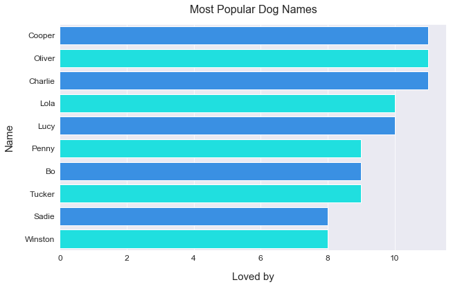

```python
plt.figure(figsize=(10,6))
sns.set_style('darkgrid')

sns.barplot(x=twitter_archive_master.name.value_counts()[:10],
            y=twitter_archive_master.name.value_counts().index[0:10], palette=["dodgerblue", "aqua"])

plt.title("Most Popular Dog Names", fontsize=16, y=1.03)
plt.xlabel('Loved by', fontsize=15, labelpad=15)
plt.ylabel('Name',  fontsize=15,labelpad=15)


plt.xticks(fontsize=12)
plt.yticks(fontsize=12);
```

#### 2. What are the most common dog stages?

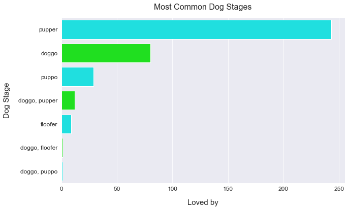

```python
plt.figure(figsize=(10,6))
sns.barplot(x=twitter_archive_master.dog_stage.value_counts(),
            y=twitter_archive_master.dog_stage.value_counts().index, palette=["aqua", "lime"])

plt.title("Most Common Dog Stages", fontsize=16, y=1.03)
plt.xlabel('Loved by', fontsize=15, labelpad=15)
plt.ylabel('Dog Stage',  fontsize=15,labelpad=15)


plt.xticks(fontsize=12)
plt.yticks(fontsize=12);
```

#### 3. What are apparently the most common dog breeds?

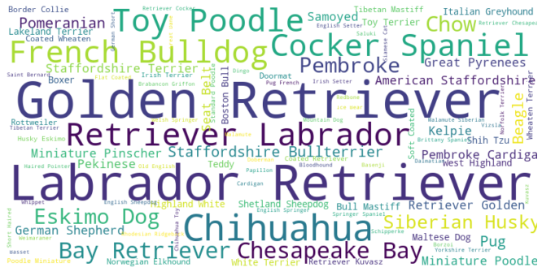

```python
# Stacking all the breed predictions into one column.
dog_breeds=twitter_archive_master[['p1', 'p2', 'p3']]
dog_breeds=dog_breeds.stack().reset_index(drop=True)

from wordcloud import WordCloud, STOPWORDS


# Instantiate word cloud object
wc = WordCloud(background_color='white', max_words=100, stopwords=STOPWORDS, scale=2)

# Generate word cloud
wc=wc.generate(' '.join(dog_breeds.to_list()))

# Show word cloud
plt.figure(figsize=(20,6))
plt.imshow(wc, interpolation='bilinear')
plt.axis("off")
plt.show()
```

#### 4. What's the favorite day of week for @WeRateDogs to post something on their twitter handle?

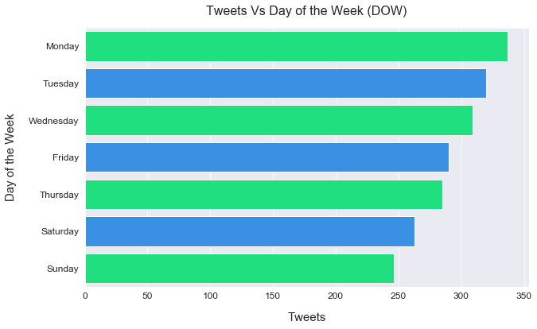

```python
twitter_archive_master['created_dow']= twitter_archive_master.timestamp.dt.day_name()
twitter_archive_master['created_hod']= twitter_archive_master.timestamp.dt.hour

plt.figure(figsize=(10,6))
sns.barplot(x=twitter_archive_master.created_dow.value_counts(),
            y=twitter_archive_master.created_dow.value_counts().index, palette=["springgreen", "dodgerblue"])

plt.title("Tweets Vs Day of the Week (DOW)", fontsize=16, y=1.03)
plt.ylabel('Day of the Week', fontsize=15, labelpad=15)
plt.xlabel('Tweets',  fontsize=15,labelpad=15)


plt.xticks(fontsize=12)
plt.yticks(fontsize=12);
```

#### 5. At which our of the day @WeRateDogs posts the most, on their twitter handle?

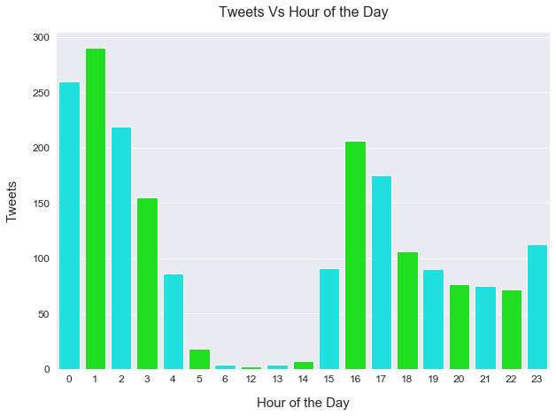

```python
twitter_archive_master['created_hod']= twitter_archive_master.timestamp.dt.hour

plt.figure(figsize=(10,7))
sns.barplot(y=twitter_archive_master.created_hod.value_counts(),
            x=twitter_archive_master.created_hod.value_counts().index, palette=["aqua", "lime"])

plt.title("Tweets Vs Hour of the Day", fontsize=16, y=1.03)
plt.xlabel('Hour of the Day', fontsize=15, labelpad=15)
plt.ylabel('Tweets',  fontsize=15,labelpad=15)


plt.xticks(fontsize=12)
plt.yticks(fontsize=12);
```

#### 6. Is there any correlation between retweet count and likes?

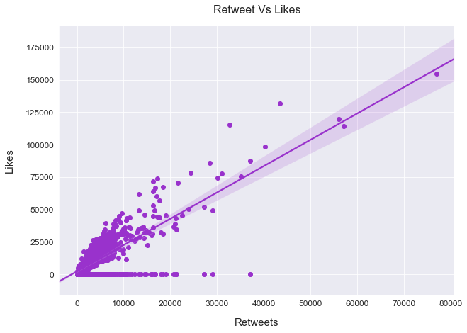

```python
plt.figure(figsize=(10,7))
sns.regplot(x="retweet_count", y="likes", data=twitter_archive_master, scatter_kws = {'alpha' : 1}, color='darkorchid')

plt.title('Retweet Vs Likes', fontsize=16, y=1.03)
plt.xlabel('Retweets', fontsize=15, labelpad=15)
plt.ylabel('Likes',  fontsize=15, rotation = 90, labelpad=15)

plt.xticks(fontsize=12)
plt.yticks(fontsize=12);
```

#### 7. What dog breeds were predicted the most by image classifier neural network?

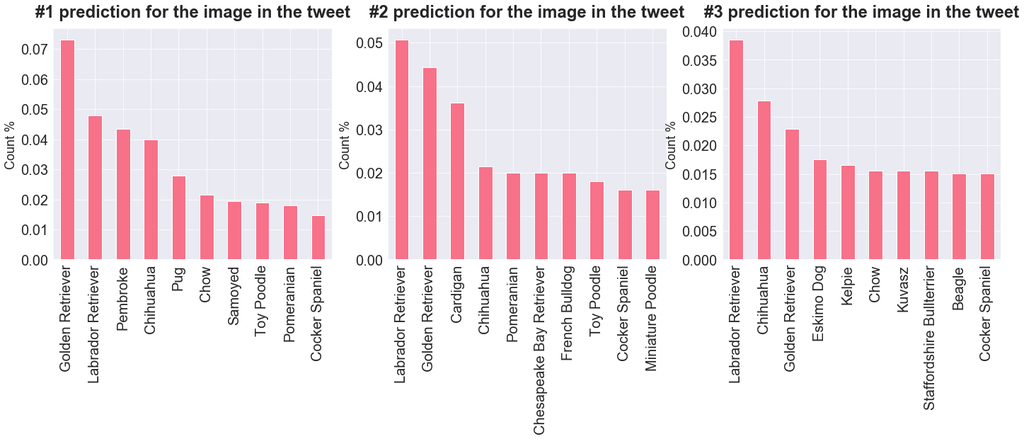

```python
plt.subplots(figsize=(10,10))
plt.subplot(1,3,1)
sns.set_palette("husl")


twitter_archive_master['p1'].value_counts(normalize=True).head(10).plot.bar(figsize=(24,6), fontsize = 20.0)
plt.title('#1 prediction for the image in the tweet', fontweight="bold", fontsize = 24.0, y=1.03)
plt.ylabel('Count %', fontsize = 18.0)

plt.subplot(1,3,2)
twitter_archive_master['p2'].value_counts(normalize=True).head(10).plot.bar(figsize=(24,6), fontsize = 20.0)
plt.title('#2 prediction for the image in the tweet', fontweight="bold", fontsize = 24.0, y=1.03)
plt.ylabel('Count %', fontsize = 18.0)

plt.subplot(1,3,3)
twitter_archive_master['p3'].value_counts(normalize=True).head(10).plot.bar(figsize=(24,6), fontsize = 20.0)
plt.title('#3 prediction for the image in the tweet', fontweight="bold", fontsize = 24.0 ,y=1.03)
plt.ylabel('Count %', fontsize = 18.0);
```